# Proceso de Preparación de y Preprocesamiento de Datos

Realizado por: *Santiago Andres Espinal Mendoza*

## Importando los paquetes para el análisis de los datos

Como primer paso, se importarán los paquetes nesesarios para el manejo de los datos como son: `pandas`, `numpy`, `matplotlib`, `seaborn`, `plotly`, `nltk`, `collections`, `wordcloud` y `string`.

```python
import pandas as pd
import numpy  as np
import matplotlib.pyplot as plt
import seaborn as sns
import plotly
from collections import Counter
from wordcloud import WordCloud
import nltk # importar el toolkit de NLP
from nltk.corpus import stopwords
nltk.download('stopwords')
nltk.download('punkt')
nltk.download('stopwords')
import string
from nltk.stem import PorterStemmer
```

Luego de importar los paquetes neseacios, con la abreviatura `pd` del paquete `pandas` leeremos el archivo`.csv` que descargamos de la aquisición de datos por medio de Web Scraping.

Utilizamos la función `.head()` para ver los datos que hay en el archivo.

```python
data = pd.read_csv('C:/Users/Acer/Desktop/OneDrive_2_9-3-2020/yelp_data12.csv')
data_copia = data.copy()
data_copia.head(10)
```

|  | DatosAdquiridos |
| --- | --- |
| 0 | ¿Qué se protege cuando se otorga una patente? ... |
| 1 | ¿Cuáles son las categorías de clasificación de... |
| 2 | ¿Quién otorga estas patentes en Colombia? + -E... |
| 3 | ¿A quién a está dirigida la convocatoria UPB I... |
| 4 | Si adelanto una investigación, ¿la puedo paten... |
| 5 | ¿Qué es el CvLAC? + -El CvLAC (Currículum Vita... |
| 6 | Si soy comunicador, filósofo, abogado o politó... |
| 7 | ¿Por qué es importante para una Universidad pa... |
| 8 | ¿Cuáles son las modalidades de proyectos de in... |
| 9 | ¿Qué es el GrupLAC? + -El GrupLAC (Grupo Latin... |

## Data Wrangling

**1. Dataset Cleaning:** Primero veremos si hay datos nulos y si los hay que los elimine.

```python
data[pd.isnull(data).any(axis=1)]
```

|  | DatosAdquiridos |
| --- | --- |

Analizamos si hay duplicados

```python
print('Dimensions before dropping duplicated rows: ' + str(data.shape))
data = data.drop(data[data.duplicated()].index)
print('Dimensions after dropping duplicated rows: ' + str(data.shape))
data[data.duplicated()]
```

```
Dimensions before dropping duplicated rows: (25, 1)
Dimensions after dropping duplicated rows: (24, 1)
```

|  | DatosAdquiridos |
| --- | --- |

**2. Dataset Structuring:** Podemos observar que la base tiene una columna llamada DatosAdquiridos, en la cual se obsera que estan las preguntas y respuestas, y que estas estan separadas por `' + -'`. Por consiguiente, realizaremos un proceso de separación de datos con la función `.split()`. Con lo anterior, añadiremos 2 columnas, una que contenga las preguntas y otra con las respuestas.

```python
x = [f.split(" + -") for f in data_copia['DatosAdquiridos']]
data_copia['Preguntas'] = [x[c][0] for c in range(len(x))]
data_copia['Respuesta'] = [x[c][1] for c in range(len(x))]
data_copia.head(5)
```

|  | DatosAdquiridos | Preguntas | Respuesta |
| --- | --- | --- | --- |
| 0 | ¿Qué se protege cuando se otorga una patente? ... | ¿Qué se protege cuando se otorga una patente? | Se protegen las \ninvenciones sean de nuevos p... |
| 1 | ¿Cuáles son las categorías de clasificación de... | ¿Cuáles son las categorías de clasificación de... | Colciencias clasifica los grupos que cumplan l... |
| 2 | ¿Quién otorga estas patentes en Colombia? + -E... | ¿Quién otorga estas patentes en Colombia? | En Colombia corresponde a la \nSuperintendenci... |
| 3 | ¿A quién a está dirigida la convocatoria UPB I... | ¿A quién a está dirigida la convocatoria UPB I... | Estructuras de \nconocimiento, docentes de cát... |
| 4 | Si adelanto una investigación, ¿la puedo paten... | Si adelanto una investigación, ¿la puedo paten... | Sí. Simplemente se \ntrata de evaluar si lo qu... |

Podemos observar que ya tenemos las dos columnas `Preguntas` y `Respuesta`, las cuales ya estan separadas y listas para ser consultadas, por lo anterior ya no tenemos nesecidad de tener la columna `DatosAdquiridos`.

```python
data_copia = data_copia.drop(columns=['DatosAdquiridos']).copy()
data_copia.head()
```

|  | Preguntas | Respuesta |
| --- | --- | --- |
| 0 | ¿Qué se protege cuando se otorga una patente? | Se protegen las \ninvenciones sean de nuevos p... |
| 1 | ¿Cuáles son las categorías de clasificación de... | Colciencias clasifica los grupos que cumplan l... |
| 2 | ¿Quién otorga estas patentes en Colombia? | En Colombia corresponde a la \nSuperintendenci... |
| 3 | ¿A quién a está dirigida la convocatoria UPB I... | Estructuras de \nconocimiento, docentes de cát... |
| 4 | Si adelanto una investigación, ¿la puedo paten... | Sí. Simplemente se \ntrata de evaluar si lo qu... |

```python
data_copia.isnull().sum()
```

```
Preguntas    0
Respuesta    0
dtype: int64
```

Ahora nos enfocaremos en las preguntas, que queremos saber algunas palabras claves o tags para luego ser como analizadas para posibles respuestas, para esto utilizaremos el paquete `WordCloud` y a unir todo el texto con el método `.join()`.

```python
word_cloud_text = ''.join(data_copia['Preguntas'])
word_cloud_text
```

```
'¿Qué se protege cuando se otorga una patente?¿Cuáles son las categorías de clasificación definidas por Colciencias para los grupos de investigación, desarrollo tecnológico o de innovación?¿Quién otorga estas patentes en Colombia?¿A quién a está dirigida la convocatoria UPB Innova?Si adelanto una in…
```

luego hacer la Tokenización de las palabras, para esto utilizaremos la función `nltk.word_tokenize()` de `nltk`:

```python
tokenized_words = nltk.word_tokenize(word_cloud_text)
tokenized_words
```

```
['¿Qué',
 'se',
 'protege',
 'cuando',
 'se',
 'otorga',
 'una',
 'patente',
 '?',
 '¿Cuáles',
 'son',
 'las',
 'categorías',
 'de',
 'clasificación',
 'definidas',
 'por',
 'Colciencias',
 'para',
 'los',
 'grupos',
 'de',
 'investigación',
 ',',
 'desarrollo',
 'tecnológico',
 'o',
 'de',
 'innovación',
 '?',
 '¿Quién',
 'otorga',
 'estas',
 'patentes',
 'en',
 'Colombia',
 '?',
 '¿A',
 'quién',
 'a',
```

[output cut: 209 more lines]

```
 '¿Quiénes',
 'pueden',
 'integrar',
 'un',
 'grupo',
 'de',
 'investigación',
 '?',
 '¿Qué',
 'es',
 'un',
 'grupo',
 'de',
 'investigación',
 '?']
```

## Stop words

A continuación vamos a eliminar las Stop Words, pero antes para esto debemos hacer una limpieza de distintos caracteres que se encontraron al momento de hacer la Tokenización de las palabra como son, `','` y `'?'`.

Luego se hacer lo anterior procedemos a remover las Stop Words con ayuda de distintos paquetes. Al finalizar realizamor una nube con las palabras sin stop words para ver una ilustración de las palaabras mas repetidas.

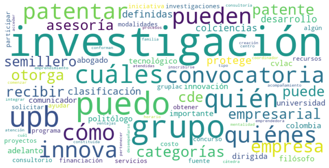

```python
palabrasL = []

for j in tokenized_words:
    palabrasL.append(j.lower().lstrip("¿"))

palabrasL.remove(",")
palabrasL.remove("?")

ord_cloud_text = ' '.join(palabrasL)
tokenized_words = nltk.word_tokenize(ord_cloud_text)

# Definiendo las stop words
stopwords = stopwords.words('spanish')

# Removiendo las stop words
word_tokens_clean = [word for word in tokenized_words if word.lower() not in stopwords and len(word.lower()) > 2]
wor = ' '.join(word_tokens_clean)
wordcloud = WordCloud(max_font_size=100, max_words=100, background_color="white",
                      width=800, height=400).generate(wor)
plt.figure(figsize=(18,6))
plt.imshow(wordcloud, interpolation="bilinear")
plt.axis("off")
plt.show()
```

Para tener un conteo de las palabras repetidas hacemos uso de la Función `Counter()`

```python
Spera = nltk.word_tokenize(wor)
word_freq = Counter(Spera)
word_freq.most_common()
```

```
[('investigación', 9),
 ('puedo', 5),
 ('grupo', 4),
 ('cuáles', 3),
 ('quién', 3),
 ('convocatoria', 3),
 ('upb', 3),
 ('patentar', 3),
 ('quiénes', 3),
 ('pueden', 3),
 ('cómo', 3),
 ('otorga', 2),
 ('categorías', 2),
 ('innova', 2),
 ('empresarial', 2),
 ('puede', 2),
 ('cde', 2),
 ('empresas', 2),
 ('recibir', 2),
 ('asesoría', 2),
 ('semillero', 2),
 ('protege', 1),
 ('patente', 1),
 ('clasificación', 1),
 ('definidas', 1),
 ('colciencias', 1),
 ('grupos', 1),
 ('desarrollo', 1),
 ('tecnológico', 1),
 ('innovación', 1),
 ('patentes', 1),
 ('colombia', 1),
 ('dirigida', 1),
 ('adelanto', 1),
 ('cvlac', 1),
 ('comunicador', 1),
 ('filósofo', 1),
 ('abogado', 1),
 ('politólogo', 1),
 ('importante', 1),
```

[output cut: 31 more lines]

```
 ('comenzar', 1),
 ('creación', 1),
 ('empresa', 1),
 ('cuál', 1),
 ('horario', 1),
 ('atención', 1),
 ('centro', 1),
 ('familia', 1),
 ('conforman', 1),
 ('ventajas', 1),
 ('pertenecer', 1),
 ('inscribirse', 1),
 ('desempeñarse', 1),
 ('coordinador', 1),
 ('integrar', 1)]
```

Al realizar todo lo anterios los datos obtenidos se enviaran a la base de Datos que tenemos.